# R Notebook

```r
# Also here we can see that some of the coefficients are set to zero.
# Make predictions on the training and testing data

lasso.train_predictions <- predict(lasso.fit, newdata = train_data, newx = lasso.predictors_train)
lasso.test_predictions <- predict(lasso.fit, newdata = test_data, newx = lasso.predictors_train)

# Calculate Mean Squared Error (MSE) for training and testing
lasso.train_mse <- mean((lasso.train_predictions - train_data$int_rate)^2)
lasso.test_mse <- mean((lasso.test_predictions - test_data$int_rate)^2)
# Calculate Root Mean Squared Error (RMSE) for training and testing
lasso.train_rmse <- sqrt(lasso.train_mse)
lasso.test_rmse <- sqrt(lasso.test_mse)

# Calculate Mean Absolute Error (MAE) for training and testing
lasso.train_mae <- mean(abs(lasso.train_predictions - train_data$int_rate))
lasso.test_mae <- mean(abs(lasso.test_predictions - test_data$int_rate))
# Calculate R-squared (R²) for training and testing
lasso.train_r2 <- 1 - (sum((train_data$int_rate - lasso.train_predictions)^2) / sum((train_data$int_rate - mean(train_data$int_rate))^2))
lasso.test_r2 <- 1 - (sum((test_data$int_rate - lasso.test_predictions)^2) / sum((test_data$int_rate - mean(test_data$int_rate))^2))
# Display the metrics
cat("Training MSE:", lasso.train_mse, "\n")
```

```
Training MSE: 12.12513
```

```r
cat("Testing MSE:", lasso.test_mse, "\n")
```

```
Testing MSE: 24.93444
```

```r
cat("Training RMSE:", lasso.train_rmse, "\n")
```

```
Training RMSE: 3.482116
```

```r
cat("Testing RMSE:", lasso.test_rmse, "\n")
```

```
Testing RMSE: 4.993439
```

```r
cat("Training MAE:", lasso.train_mae, "\n")
```

```
Training MAE: 2.767999
```

```r
cat("Testing MAE:", lasso.test_mae, "\n")
```

```
Testing MAE: 3.995769
```

```r
cat("Training R-squared (R²):", lasso.train_r2, "\n")
```

```
Training R-squared (R²): -43.19514
```

```r
cat("Testing R-squared (R²):", lasso.test_r2, "\n")
```

```
Testing R-squared (R²): -362.708
```

K fold

```r
# Perform k-fold cross-validation
for(i in seq_along(folds)) {
  # Split the data into training and testing for the current fold
  train_indices <- folds[[i]]
  test_indices <- setdiff(seq_len(nrow(train_data)), train_indices)

  train_data_fold <- train_data[train_indices, ]
  test_data_fold <- train_data[test_indices, ]

  # Fit the model on the training fold
  lm_model <- lm(int_rate ~ ., data = train_data_fold)
  models[[i]] <- lm_model  # Store the model

  # Make predictions on the training and testing fold
  train_predictions <- predict(lm_model, newdata = train_data_fold)
  test_predictions <- predict(lm_model, newdata = test_data_fold)

  # Calculate metrics for training fold
  train_mse <- mean((train_predictions - train_data_fold$int_rate)^2)
  train_rmse <- sqrt(train_mse)
  train_mae <- mean(abs(train_predictions - train_data_fold$int_rate))
  train_r2 <- summary(lm_model)$r.squared

  # Calculate metrics for testing fold
  test_mse <- mean((test_predictions - test_data_fold$int_rate)^2)
  test_rmse <- sqrt(test_mse)
  test_mae <- mean(abs(test_predictions - test_data_fold$int_rate))
  test_r2 <- 1 - (sum((test_data_fold$int_rate - test_predictions)^2) / sum((test_data_fold$int_rate - mean(test_data_fold$int_rate))^2))

  # Store metrics in the results dataframe
  results <- rbind(results, data.frame(
    Fold = i,
    Train_MSE = train_mse, Test_MSE = test_mse,
    Train_RMSE = train_rmse, Test_RMSE = test_rmse,
    Train_MAE = train_mae, Test_MAE = test_mae,
    Train_R2 = train_r2, Test_R2 = test_r2
  ))
}

# Display the models and their metrics
print(models)
```

```
[[1]]

Call:
lm(formula = int_rate ~ ., data = train_data_fold)

Coefficients:
                    (Intercept)                        loan_amnt
                      3.687e+00                        3.469e-05
                           term                       emp_length
                      3.915e+00                        9.005e-03
                 home_ownership              verification_status
                      2.551e-01                        7.508e-01
                        purpose                       addr_state
                      3.347e-01                        6.467e-04
                    delinq_2yrs                 earliest_cr_line
                      3.082e-02                        1.932e-09
                 inq_last_6mths                         open_acc
                      9.691e-01                        6.753e-02
                        pub_rec                        revol_bal
                      3.904e-01                        5.428e-06
                     revol_util                        total_acc
                      4.194e-02                       -3.724e-02
            initial_list_status       collections_12_mths_ex_med
                     -1.049e+00                        1.512e-01
                 acc_now_delinq                     tot_coll_amt
                      6.782e-01                        3.681e-05
                    tot_cur_bal                      open_acc_6m
                     -1.095e-06                       -1.567e-01
                     open_il_6m                      open_il_12m
                     -1.305e-01                        7.125e-01
                    open_il_24m               mths_since_rcnt_il
                     -8.877e-02                       -3.827e-03
                   total_bal_il                          il_util
                      1.514e-06                        3.403e-04
                    open_rv_12m                      open_rv_24m
                      2.705e-01                        2.294e-02
                     max_bal_bc                         all_util
                     -7.473e-05                       -5.008e-03
               total_rev_hi_lim                           inq_fi
                     -1.764e-05                       -1.048e-03
```

[output cut: 443 more lines]

```
                      2.294e-06                       -5.317e-03
                    open_rv_12m                      open_rv_24m
                      1.104e-01                        8.015e-02
                     max_bal_bc                         all_util
                     -6.980e-05                        1.842e-03
               total_rev_hi_lim                           inq_fi
                     -1.754e-05                       -2.145e-02
                    total_cu_tl                     inq_last_12m
                     -6.802e-02                        4.283e-02
              annual_inc_merged                       dti_merged
                     -2.587e-06                        5.252e-02
          mths_since_delinq_cat       mths_since_last_record_cat
                     -2.019e-01                       -1.620e-01
mths_since_last_major_derog_cat
                     -1.377e-01
```

```r
print(results)
```

| Fold | Train_MSE | Test_MSE | Train_RMSE | Test_RMSE | Train_MAE | Test_MAE | Train_R2 | Test_R2 |
| --- | --- | --- | --- | --- | --- | --- | --- | --- |
| 1 | 10.70909 | 10.74920 | 3.272475 | 3.278598 | 2.591264 | 2.588019 | 0.4463835 | 0.4398351 |
| 2 | 10.58788 | 10.74221 | 3.253902 | 3.277532 | 2.581346 | 2.588932 | 0.4473361 | 0.4408014 |
| 3 | 10.54086 | 10.78678 | 3.246668 | 3.284323 | 2.576798 | 2.584858 | 0.4490037 | 0.4385704 |
| 4 | 10.70019 | 10.73557 | 3.271114 | 3.276519 | 2.596882 | 2.600397 | 0.4422397 | 0.4410621 |
| 5 | 10.66905 | 10.74666 | 3.266351 | 3.278209 | 2.581581 | 2.587851 | 0.4460019 | 0.4402454 |
| 6 | 10.63589 | 10.73384 | 3.261271 | 3.276254 | 2.587542 | 2.587533 | 0.4437887 | 0.4413534 |
| 7 | 10.58449 | 10.74916 | 3.253381 | 3.278592 | 2.582349 | 2.587308 | 0.4493728 | 0.4402303 |
| 8 | 10.77137 | 10.74163 | 3.281977 | 3.277442 | 2.594648 | 2.587550 | 0.4409404 | 0.4404791 |
| 9 | 10.75606 | 10.72103 | 3.279643 | 3.274299 | 2.605394 | 2.599914 | 0.4389397 | 0.4418619 |
| 10 | 10.59623 | 10.75811 | 3.255186 | 3.279955 | 2.584962 | 2.590418 | 0.4478420 | 0.4398684 |

```r
NA
```

Decision Tree

```r
#### Decision Trees ####

# Error in tree: "factor predictors must have at most 32 levels" is thrown.
# Basically, it becomes computationally expensive to create so many splits in your data, since you are selecting the best split out of all 2^32 (approx) possible splits.


# Fit a decision tree model on the training data
#tm <- tree(int_rate ~ ., data = train_data)

# Make predictions on the training and testing data
#tm.train_predictions <- predict(tm, newdata = train_data)
#tm.test_predictions <- predict(tm, newdata = test_data)

# Calculate Mean Squared Error (MSE) for training and testing
#tm.train_mse <- mean((tm.train_predictions - train_data$int_rate)^2)
#tm.test_mse <- mean((tm.test_predictions - test_data$int_rate)^2)

# Calculate Root Mean Squared Error (RMSE) for training and testing
#tm.train_rmse <- sqrt(tm.train_mse)
#tm.test_rmse <- sqrt(tm.test_mse)

# Calculate Mean Absolute Error (MAE) for training and testing
#tm.train_mae <- mean(abs(tm.train_predictions - train_data$int_rate))
#tm.test_mae <- mean(abs(tm.test_predictions - test_data$int_rate))

# Calculate R-squared (R²) for training and testing
#tm.train_r2 <- 1 - (sum((train_data$int_rate - tm.train_predictions)^2) / sum((train_data$int_rate - mean(train_data$int_rate))^2))
#tm.test_r2 <- 1 - (sum((test_data$int_rate - tm.test_predictions)^2) / sum((test_data$int_rate - mean(test_data$int_rate))^2))

# Display the metrics
#cat("Training MSE:", tm.train_mse, "\n")
#cat("Testing MSE:", tm.test_mse, "\n")
#cat("Training RMSE:", tm.train_rmse, "\n")
#cat("Testing RMSE:", tm.test_rmse, "\n")
#cat("Training MAE:", tm.train_mae, "\n")
#cat("Testing MAE:", tm.test_mae, "\n")
#cat("Training R-squared (R²):", tm.train_r2, "\n")
#cat("Testing R-squared (R²):", tm.test_r2, "\n")
```

Random Forest

```r
#### Random Forest ####

# Train a Random Forest model
rf <- ranger(formula = int_rate ~ ., data = train_data, num.trees = 500, verbose=TRUE, importance = "impurity", oob.error = TRUE)
# Print the model summary
print("Random Forest Model Summary:")
```

```
[1] "Random Forest Model Summary:"
```

```r
print(rf)
```

```
Ranger result

Call:
 ranger(formula = int_rate ~ ., data = train_data, num.trees = 500,      verbose = TRUE, importance = "impurity", oob.error = TRUE)

Type:                             Regression
Number of trees:                  500
Sample size:                      638392
Number of independent variables:  40
Mtry:                             6
Target node size:                 5
Variable importance mode:         impurity
Splitrule:                        variance
OOB prediction error (MSE):       8.744647
R squared (OOB):                  0.5446644
```

```r
# Make predictions on the training and testing data
rf.train_predictions <- predict(rf, data = train_data)
```

```
Predicting.. Progress: 81%. Estimated remaining time: 7 seconds.
```

```r
rf.test_predictions <- predict(rf, data = test_data)

# Calculate Mean Squared Error (MSE) for training and testing
rf.train_mse <- mean((rf.train_predictions$predictions - train_data$int_rate)^2)
rf.test_mse <- mean((rf.test_predictions$predictions - test_data$int_rate)^2)

# Calculate Root Mean Squared Error (RMSE) for training and testing
rf.train_rmse <- sqrt(rf.train_mse)
rf.test_rmse <- sqrt(rf.test_mse)

# Calculate Mean Absolute Error (MAE) for training and testing
rf.train_mae <- mean(abs(rf.train_predictions$predictions - train_data$int_rate))
rf.test_mae <- mean(abs(rf.test_predictions$predictions - test_data$int_rate))

# Calculate R-squared (R²) for training and testing
rf.train_r2 <- 1 - (sum((train_data$int_rate - rf.train_predictions$predictions)^2) / sum((train_data$int_rate - mean(train_data$int_rate))^2))
rf.test_r2 <- 1 - (sum((test_data$int_rate - rf.test_predictions$predictions)^2) / sum((test_data$int_rate - mean(test_data$int_rate))^2))

# Display the metrics
cat("Training MSE:", rf.train_mse, "\n")
```

```
Training MSE: 2.066856
```

```r
cat("Testing MSE:", rf.test_mse, "\n")
```

```
Testing MSE: 8.69323
```

```r
cat("Training RMSE:", rf.train_rmse, "\n")
```

```
Training RMSE: 1.437656
```

```r
cat("Testing RMSE:", rf.test_rmse, "\n")
```

```
Testing RMSE: 2.948428
```

```r
cat("Training MAE:", rf.train_mae, "\n")
```

```
Training MAE: 1.130191
```

```r
cat("Testing MAE:", rf.test_mae, "\n")
```

```
Testing MAE: 2.331673
```

```r
cat("Training R-squared (R²):", rf.train_r2, "\n")
```

```
Training R-squared (R²): 0.8923782
```

```r
cat("Testing R-squared (R²):", rf.test_r2, "\n")
```

```
Testing R-squared (R²): 0.5471326
```

```r
#rf <- randomForest(int_rate~., data=train_data, ntree = 5, mtry = 3)
#bag.boston=randomForest(medv~.,data=Boston,subset=train, mtry=13,importance =TRUE)
#print(rf)

# Set the number of cores you want to use
#num_cores <- 6  # Adjust this number based on your system's capabilities

# Register parallel backend
#cl <- makeCluster(num_cores)
#registerDoParallel(cl)

# Assuming 'lc_data' is your dataset
#rf_model <- foreach(ntree = rep(100, num_cores), .packages = 'randomForest') %dopar% {
#    randomForest(int_rate ~ ., data = lc_data, ntree = ntree, mtry = sqrt(ncol(lc_data)))
#}

# After training, stop the cluster to release the cores:
#stopCluster(cl)
```

Boosting

```r
#### Boosting ####

# Define the target variable for training and testing
xgb.y_train <- train_data$int_rate
xgb.y_test <- test_data$int_rate  # Use test_data for testing

# Define the feature matrix for training and testing (exclude the target variable)
xgb.X_train <- train_data[, -which(names(train_data) == 'int_rate')]
xgb.X_test <- test_data[, -which(names(test_data) == 'int_rate')]  # Use test_data for testing

# Fit a gradient boosting regression model using xgboost
xgb <- xgboost(
  data = as.matrix(xgb.X_train),
  label = xgb.y_train,
  nrounds = 100,
  verbose = 0
)

# Make predictions on the training and testing data
xgb.train_predictions <- predict(xgb, newdata = as.matrix(xgb.X_train))
xgb.test_predictions <- predict(xgb, newdata = as.matrix(xgb.X_test))

# Calculate Mean Squared Error (MSE) for training and testing
xgb.train_mse <- mean((xgb.train_predictions - xgb.y_train)^2)
xgb.test_mse <- mean((xgb.test_predictions - xgb.y_test)^2)

# Calculate Root Mean Squared Error (RMSE) for training and testing
xgb.train_rmse <- sqrt(xgb.train_mse)
xgb.test_rmse <- sqrt(xgb.test_mse)

# Calculate Mean Absolute Error (MAE) for training and testing
xgb.train_mae <- mean(abs(xgb.train_predictions - xgb.y_train))
xgb.test_mae <- mean(abs(xgb.test_predictions - xgb.y_test))

# Calculate R-squared (R²) for training and testing
xgb.train_r2 <- 1 - (sum((xgb.y_train - xgb.train_predictions)^2) / sum((xgb.y_train - mean(xgb.y_train))^2))
xgb.test_r2 <- 1 - (sum((xgb.y_test - xgb.test_predictions)^2) / sum((xgb.y_test - mean(xgb.y_test))^2))

# Display the metrics
cat("Training MSE:", xgb.train_mse, "\n")
```

```
Training MSE: 7.70773
```

```r
cat("Testing MSE:", xgb.test_mse, "\n")
```

```
Testing MSE: 8.007011
```

```r
cat("Training RMSE:", xgb.train_rmse, "\n")
```

```
Training RMSE: 2.77628
```

```r
cat("Testing RMSE:", xgb.test_rmse, "\n")
```

```
Testing RMSE: 2.829666
```

```r
cat("Training MAE:", xgb.train_mae, "\n")
```

```
Training MAE: 2.179231
```

```r
cat("Testing MAE:", xgb.test_mae, "\n")
```

```
Testing MAE: 2.219719
```

```r
cat("Training R-squared (R²):", xgb.train_r2, "\n")
```

```
Training R-squared (R²): 0.5986562
```

```r
cat("Testing R-squared (R²):", xgb.test_r2, "\n")
```

```
Testing R-squared (R²): 0.5828808
```

Following, a scatter plot of actual vs predicted training values for each model is plot. This plot helps us visualize how well each model’s predictions align with the actual data points.

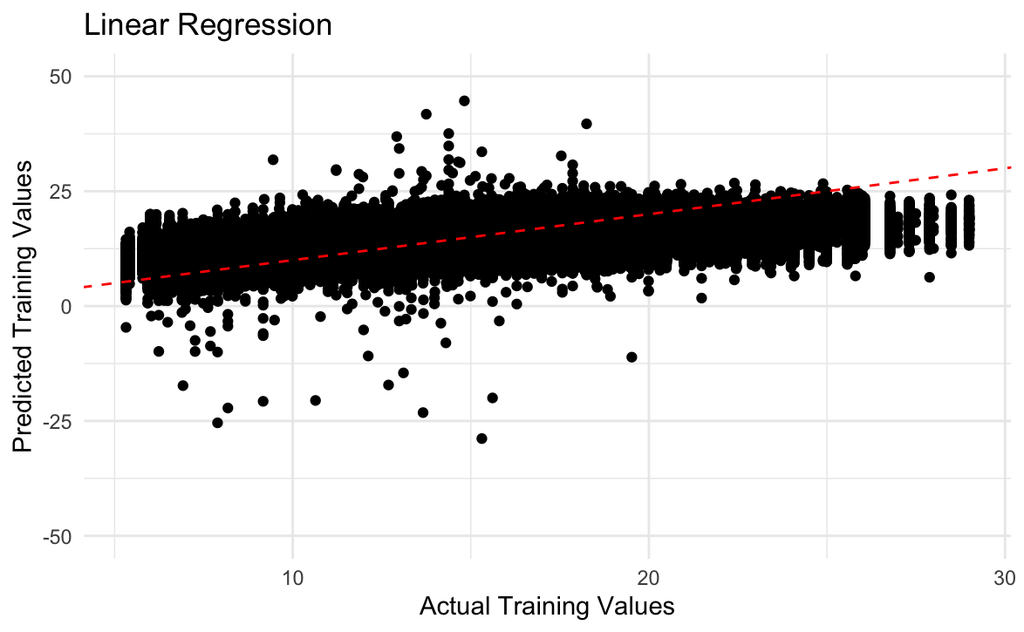

```r
# Create a scatter plot function
create_scatter_plot <- function(actual_values, predicted_values, model_name) {
  model_comparison_data <- data.frame(
    Actual = actual_values,
    Predicted = predicted_values
  )

  scatter_plot <- ggplot(model_comparison_data, aes(x = Actual, y = Predicted)) +
    geom_point() +
    geom_abline(intercept = 0, slope = 1, linetype = "dashed", color = "red") +  # Add a diagonal reference line
    labs(x = "Actual Training Values", y = "Predicted Training Values", title = model_name) +
    theme_minimal() +
    ylim(-50, 50)

  return(scatter_plot)
}

# Create scatter plots for each model
lm_scatter_plot <- create_scatter_plot(
  actual_values = train_data$int_rate,
  predicted_values = lm.train_predictions,
  model_name = "Linear Regression"
)

rf_scatter_plot <- create_scatter_plot(
  actual_values = train_data$int_rate,
  predicted_values = rf.train_predictions$predictions,
  model_name = "Random Forest"
)

xgb_scatter_plot <- create_scatter_plot(
  actual_values = xgb.y_train,
  predicted_values = xgb.train_predictions,
  model_name = "XGBoost"
)

# Display the scatter plots separately
print(lm_scatter_plot)
```

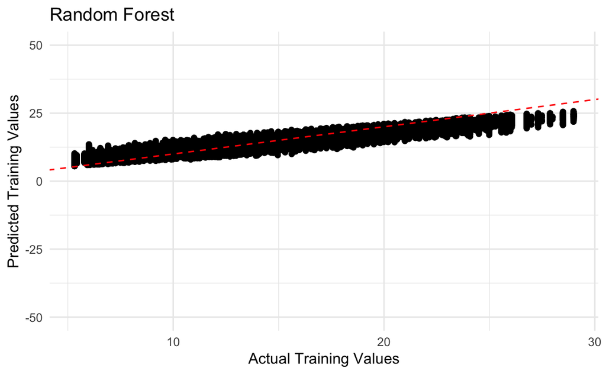

```r
print(rf_scatter_plot)
```

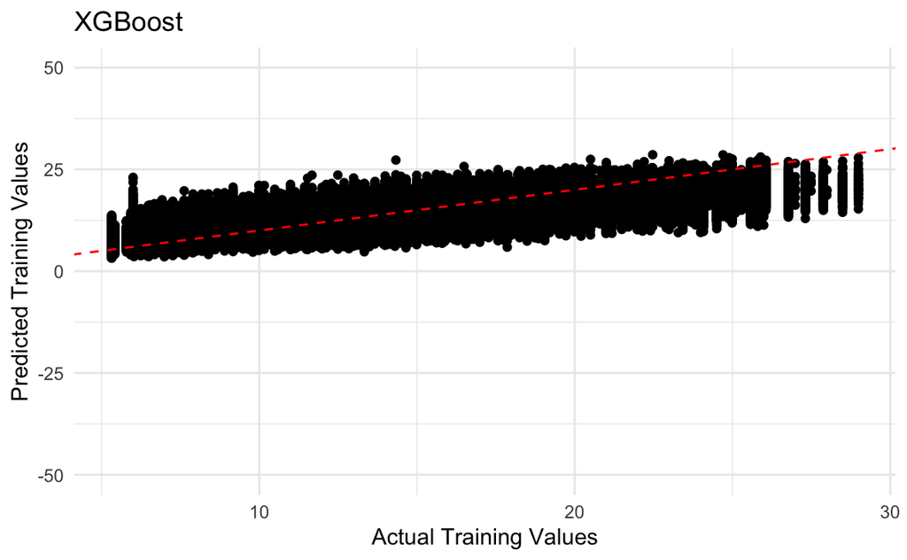

```r
print(xgb_scatter_plot)
```

Following, a scatter plot of actual vs predicted testing values for each model is plot. This plot helps us visualize how well each model’s predictions align with the actual data points.

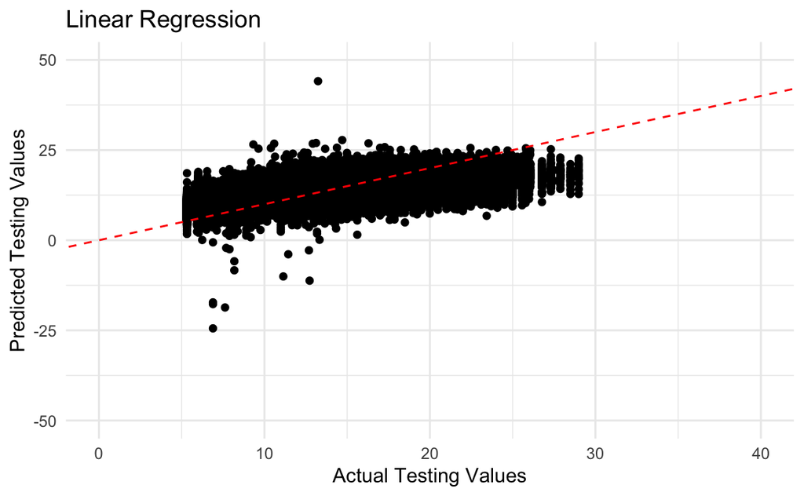

```r
# Create a scatter plot function
create_scatter_plot <- function(actual_values, predicted_values, model_name) {
  model_comparison_data <- data.frame(
    Actual = actual_values,
    Predicted = predicted_values
  )

  scatter_plot <- ggplot(model_comparison_data, aes(x = Actual, y = Predicted)) +
    geom_point() +
    geom_abline(intercept = 0, slope = 1, linetype = "dashed", color = "red") +  # Add a diagonal reference line
    labs(x = "Actual Testing Values", y = "Predicted Testing Values", title = model_name) +
    theme_minimal() +
    ylim(-50, 50) +
    xlim(0, 40)

  return(scatter_plot)
}

# Create scatter plots for each model
lm_scatter_plot <- create_scatter_plot(
  actual_values = test_data$int_rate,
  predicted_values = lm.test_predictions,
  model_name = "Linear Regression"
)

rf_scatter_plot <- create_scatter_plot(
  actual_values = test_data$int_rate,
  predicted_values = rf.test_predictions$predictions,
  model_name = "Random Forest"
)

xgb_scatter_plot <- create_scatter_plot(
  actual_values = xgb.y_test,
  predicted_values = xgb.test_predictions,
  model_name = "XGBoost"
)

# Display the scatter plots separately
print(lm_scatter_plot)
```

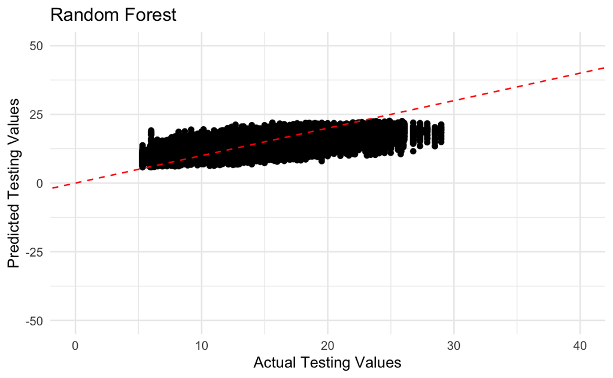

```r
print(rf_scatter_plot)
```